# Crash Course in Linear Models

Jon Yearsley, Adam Kane & Graham Hughes

Nov 2022

# Data analysis workflow

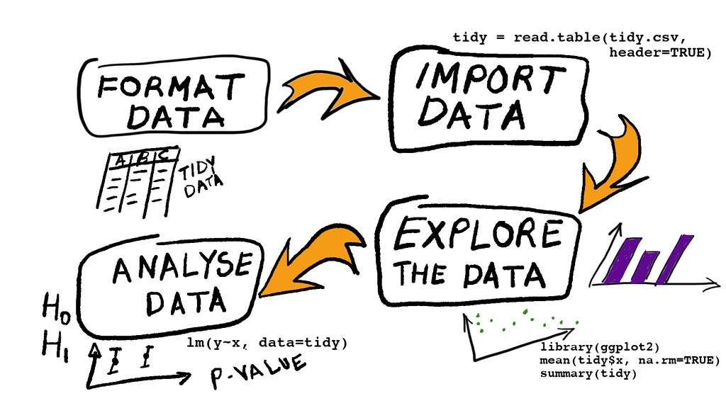

The four steps in the workflow of a data analysis project

In this crash course we’re going to concentrate upon steps 3 and 4 of the workflow

# Steps 1 & 2: Tidy and import your data

The data are in a “comma-separated variable” format which is relatively easy to import using R’s import functions (e.g. `read.table()` or `read.csv()`).

```r
# Import climate data for six European cities for the period 1970-2022
climate = read.table('climate_change.csv',
                     sep=',',
                     header=TRUE)
```

Check that the imported data look OK.

Look at the first few lines of data

```r
# Look at first 6 lines of the imported data
head(climate)
```

```
##   year location longitude latitude summer_dailyTmean winter_dailyTmean
## 1 1970   Dublin   -6.2603  53.3498          14.47758          3.929986
## 2 1970   Madrid   -3.7038  40.4168          21.81309          4.472604
## 3 1970   London   -0.1276  51.5072          16.22327          3.666312
## 4 1970     Oslo   10.7522  59.9139          14.82735         -8.384096
## 5 1970   Berlin   13.4050  52.5200          17.93198         -1.952514
## 6 1970     Rome   12.4964  41.9028          22.37599          7.703991
##   summer_dailyRainfall winter_dailyRainfall
## 1            2.2880435            3.0379167
## 2            0.5679348            2.0715278
## 3            1.5138587            1.9497223
## 4            3.0078261            0.8481482
## 5            1.1076087            1.4516667
## 6            0.8355351            4.2196582
```

Now look at a summary of the data

```r
# A summary of the data
summary(climate)
```

```
##       year        location           longitude         latitude
##  Min.   :1970   Length:318         Min.   :-6.260   Min.   :40.42
##  1st Qu.:1983   Class :character   1st Qu.:-3.704   1st Qu.:41.90
##  Median :1996   Mode  :character   Median : 5.312   Median :52.01
##  Mean   :1996                      Mean   : 4.427   Mean   :49.94
##  3rd Qu.:2009                      3rd Qu.:12.496   3rd Qu.:53.35
##  Max.   :2022                      Max.   :13.405   Max.   :59.91
##  summer_dailyTmean winter_dailyTmean summer_dailyRainfall winter_dailyRainfall
##  Min.   :12.44     Min.   :-10.535   Min.   :0.02729      Min.   :0.2456
##  1st Qu.:14.95     1st Qu.:  1.231   1st Qu.:0.86331      1st Qu.:1.4064
##  Median :17.27     Median :  4.979   Median :1.65221      Median :1.8776
##  Mean   :18.25     Mean   :  3.393   Mean   :1.67505      Mean   :2.0645
##  3rd Qu.:22.11     3rd Qu.:  6.159   3rd Qu.:2.32592      3rd Qu.:2.5086
##  Max.   :26.08     Max.   :  9.411   Max.   :4.63783      Max.   :5.5355
```

And the structure of the data frame, showing the data types

```r
# The structure of the data
str(climate)
```

```
## 'data.frame':    318 obs. of  8 variables:
##  $ year                : int  1970 1970 1970 1970 1970 1970 1971 1971 1971 1971 ...
##  $ location            : chr  "Dublin" "Madrid" "London" "Oslo" ...
##  $ longitude           : num  -6.26 -3.704 -0.128 10.752 13.405 ...
##  $ latitude            : num  53.3 40.4 51.5 59.9 52.5 ...
##  $ summer_dailyTmean   : num  14.5 21.8 16.2 14.8 17.9 ...
##  $ winter_dailyTmean   : num  3.93 4.47 3.67 -8.38 -1.95 ...
##  $ summer_dailyRainfall: num  2.288 0.568 1.514 3.008 1.108 ...
##  $ winter_dailyRainfall: num  3.038 2.072 1.95 0.848 1.452 ...
```

## Wrangling the data

Location is a qualitative variable, so make sure this is set to be a `factor`

```r
# Make sure location is a factor
climate$location = as.factor(climate$location)
```

Let’s also add a variable that defines two periods: 1970-1979 and 2010-2019

```r
# Define two time periods
climate$period = NA
climate$period[climate$year>=1970 & climate$year<1980] = "1970s"
climate$period[climate$year>=2010 & climate$year<2020] = "2010s"
climate$period = as.factor(climate$period)
```

And we’ll produce a subset that’s just data for Dublin

```r
dublin_climate = subset(climate, location=="Dublin")
```

# Step 3: Explore your data

Plotting the data is a great way to explore the data

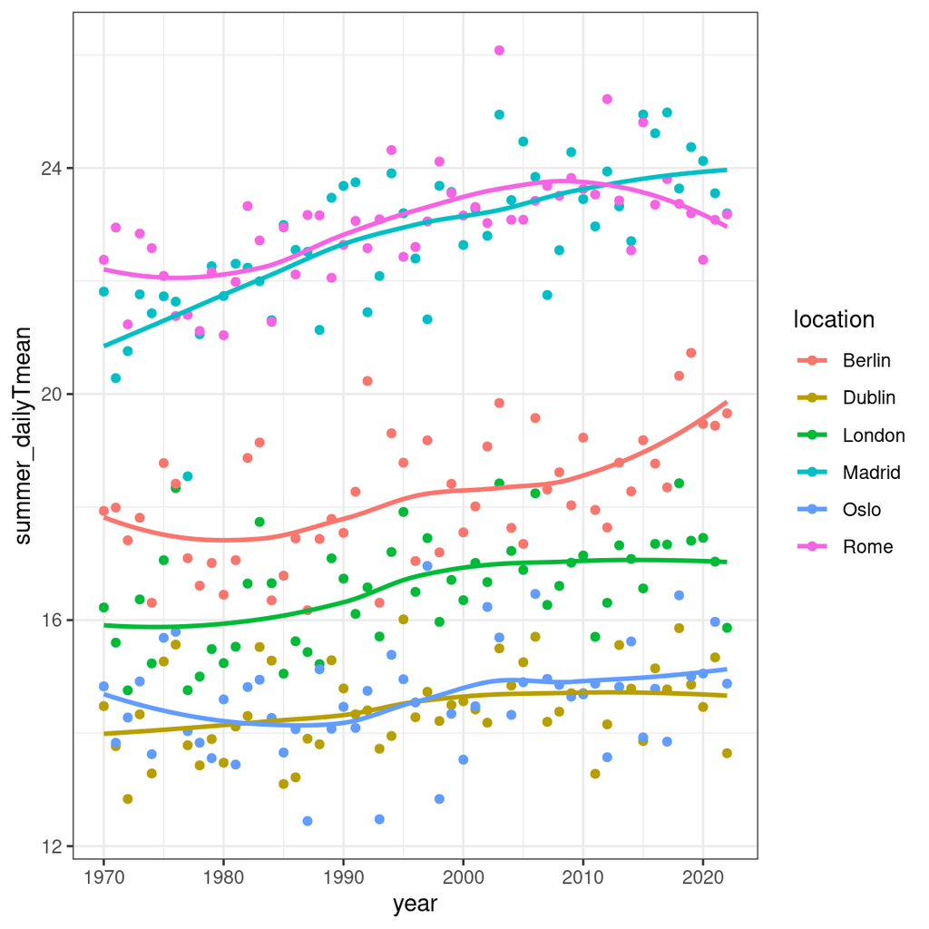

```r
library(ggplot2)

# Plot mean temperature for the six locations
ggplot(data=climate,
       aes(x=year,
           y=summer_dailyTmean,
           colour=location)) +
  geom_point() +
  geom_smooth(se=FALSE) +
  theme_bw()
```

Looks like temperatures are increasing in some locations, but maybe not all.

Another figure that compares the 1970s to the 2010s for Dublin

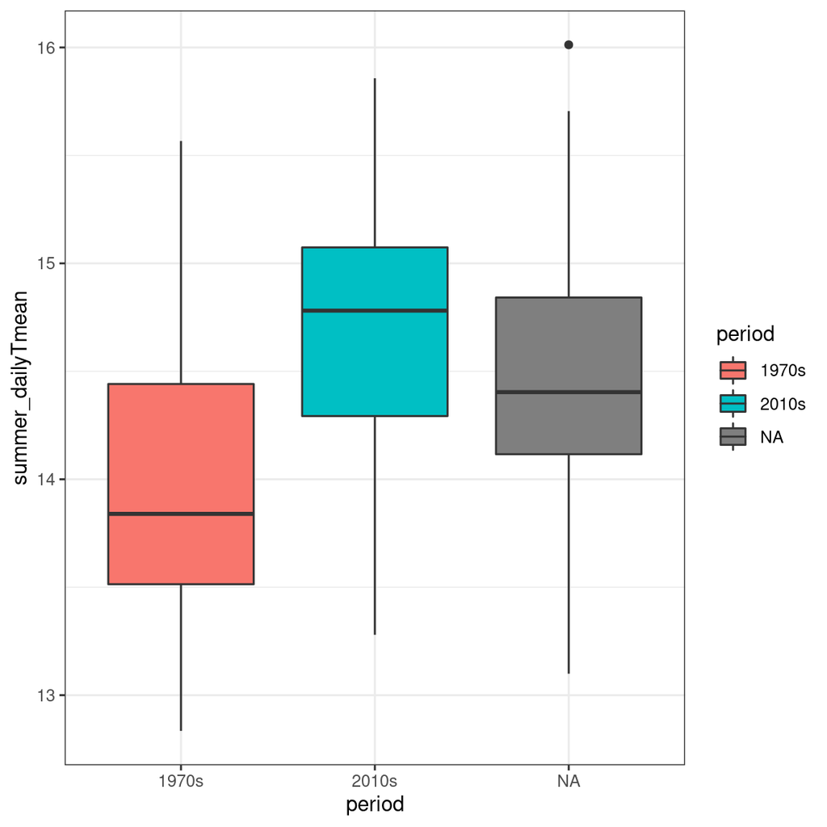

```r
# Plot mean temperature for the six locations
ggplot(data=dublin_climate,
       aes(x=period,
           y=summer_dailyTmean,
           fill=period)) +
  geom_boxplot() +
  theme_bw()
```

# Step 4: Analyse the data

We’ll investigate whether:

> the summer daily mean temperature for Dublin (the **response variable**) has been linearly increasing with year (the **explanatory variable**) between 1970 and 2022.

For this we will use a **linear model** to describe the summer daily mean temperature for Dublin form 1970 to 2022.

The model is described by the formula `response ~ 1 + explanatory`, where `response` is the name of the response variable and `explanatory` is the name of the explanatory variable.

We use the `lm()` command to fit the model:

```r
# Fit a linear regression model for mean daily temperature in Dublin
m_dublin = lm(summer_dailyTmean~1+year,
              data=dublin_climate)
```

## Validate the model

In order to use the model to draw reliable conclusions about Dublin’s climate we must ensure that the model is able to generate data that is reasonably realistic.

In other words we must validate that the model’s assumptions are reasonably valid.

Some important assumptions are:

1. The residuals from the fitted model are independent of one another (independence assumption)
2. The variance of residuals from the fitted model is the same across all values of the explanatory variables (homogeneity of variance assumption)
3. The residuals from the model follow a normal distribution (normality assumption)
4. A linear relationship is an appropriate description
5. The is little uncertainty in the values of the explanatory variable

### Residual versus fitted validation plot

Test whether:

- variance is homogeneous
- the linear relationship is appropriate

using a residual versus fitted plot

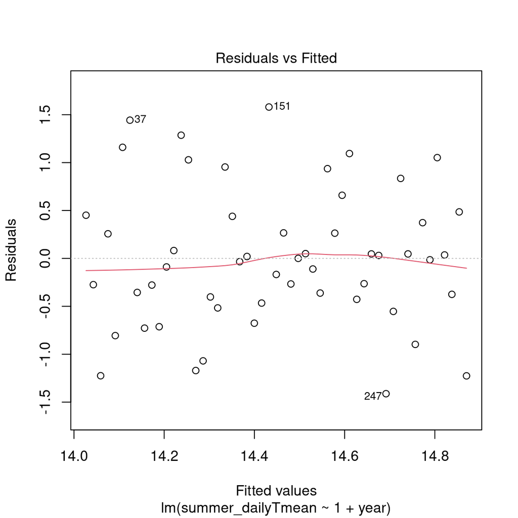

```r
# Ptot a residual versus fitted
plot(m_dublin, which=1)
```

### Quantile-Quantile validation plot

Test whether:

- residuals follow a normal distribution

using a Q-Q plot

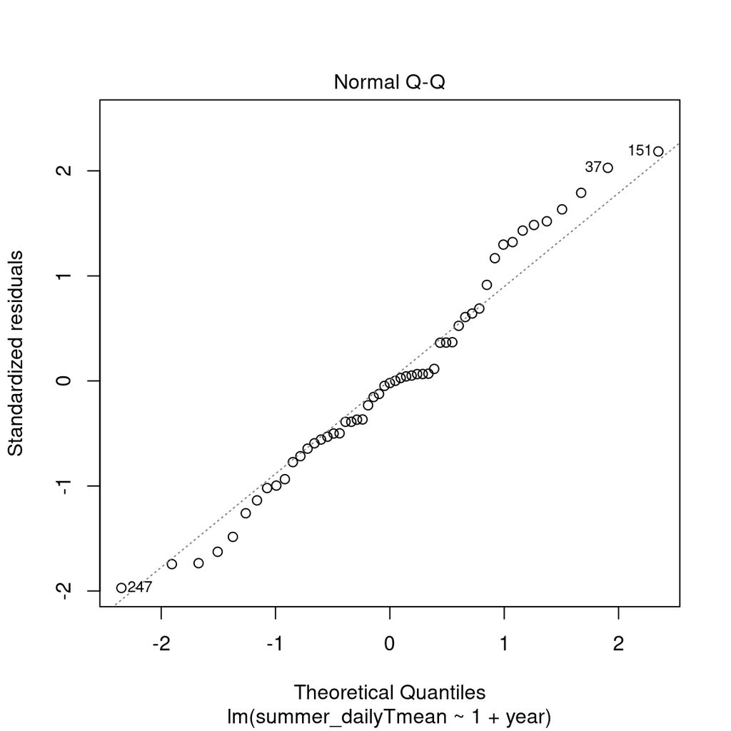

```r
# Plot a residual versus fitted
plot(m_dublin, which=2)
```

### Leverage plot

Test whether:

- any one data point is having too much influence on the model fit

using a Cook’s distance leverage plot.

This isn’t an assumption of the model, but it ensures that our result comes from the bulk of our data, not one or two data points.

Here’s the plot

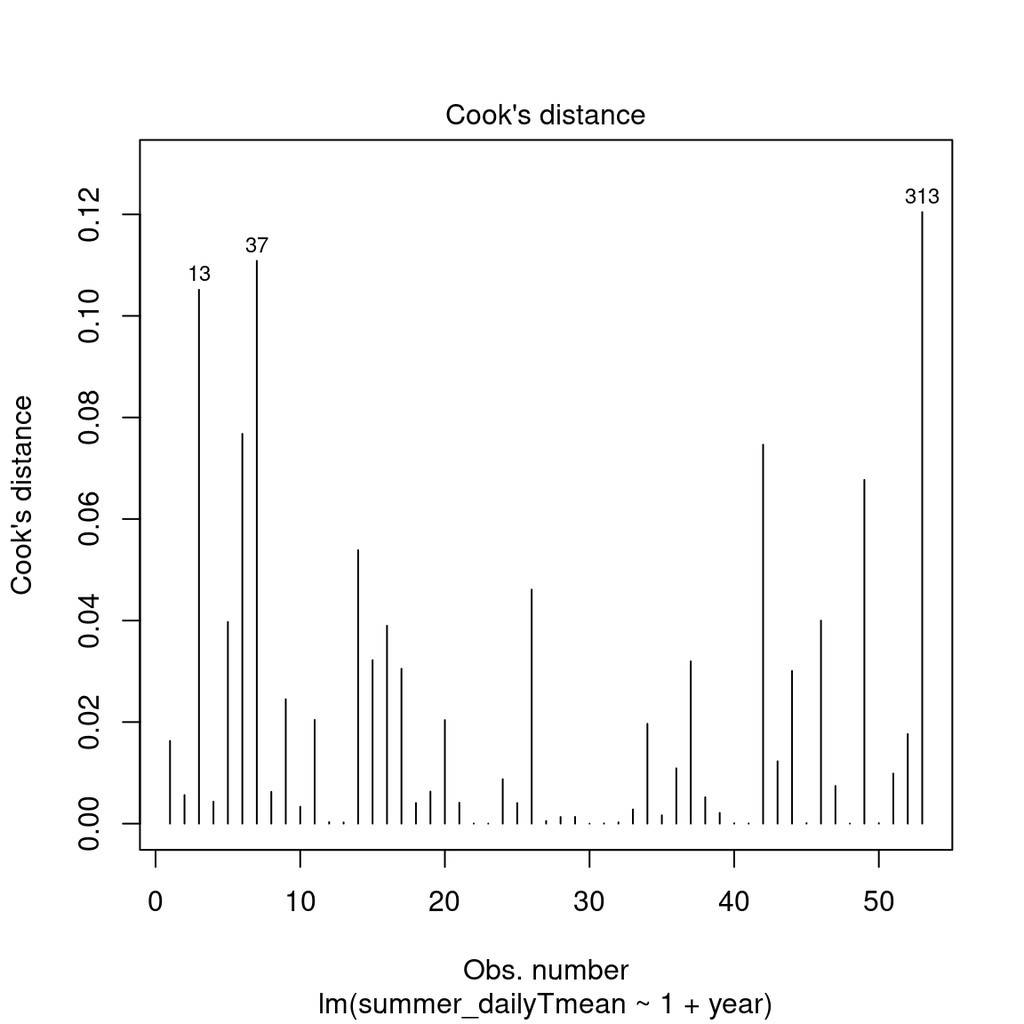

```r
# A leverage plot showing Cook's distance
plot(m_dublin, which=4)
```

Cook’s distance greater than 1 indicates observations that have a large effect on the fitted model. All looks good here.

## Hypothesis test

Yay. We have a valid model, so now we can start using it to ask questions about the world (in this case Dublin’s climate over the last 50 years).

> First question: Has Dublin’s summer temperature been increasing from 1970 until 2022?

We turn this question into a hypothesis:

> H<sub>1</sub>: The summer daily mean temperature in Dublin has linearly increased from 1970 until 2022

and write the corresponding null-hypothesis

> H<sub>0</sub>: The summer daily mean temperature in Dublin has no relationship with year between 1970 and 2022

We’ve already fitted the model that corresponds to the hypothesis (that’s our model `m_dublin`).

So now we fit the model for the null-hypothesis, which means removing `year` as an explanatory variable

```r
# Fit the null model
m_null = lm(summer_dailyTmean~1,
              data=dublin_climate)
```

We then **test the null-hypothesis** by comparing the null-model (`m_null`) to the full-model (`m_dublin`) using the `anova()` function.

```r
anova(m_null, m_dublin)
```

```
## Analysis of Variance Table
##
## Model 1: summer_dailyTmean ~ 1
## Model 2: summer_dailyTmean ~ 1 + year
##   Res.Df    RSS Df Sum of Sq      F  Pr(>F)
## 1     52 30.451
## 2     51 27.188  1    3.2638 6.1224 0.01672 *
## ---
## Signif. codes:  0 '***' 0.001 '**' 0.01 '*' 0.05 '.' 0.1 ' ' 1
```

P-value (=0.017) is less than 5%, so we have evidence to **reject the null-hypothesis**. Summer mean daily temperature in Dublin has increased from 1970 until 2022.

## Estimating the Effect Size

So we conclude that summer temperatures have been increasing. The next question is:

> How quickly have temperatures been increasing in Dublin?

This is a question asking us to **estimate** the slope of the linear relationship between temperature and year (this slope is the **effect size** that is of interest).

For this we must look at a summary of the full-model.

```r
summary(m_dublin)
```

```
##
## Call:
## lm(formula = summer_dailyTmean ~ 1 + year, data = dublin_climate)
##
## Residuals:
##      Min       1Q   Median       3Q      Max
## -1.41208 -0.42717 -0.01429  0.43912  1.58011
##
## Coefficients:
##               Estimate Std. Error t value Pr(>|t|)
## (Intercept) -17.931258  13.086594  -1.370   0.1766
## year          0.016222   0.006556   2.474   0.0167 *
## ---
## Signif. codes:  0 '***' 0.001 '**' 0.01 '*' 0.05 '.' 0.1 ' ' 1
##
## Residual standard error: 0.7301 on 51 degrees of freedom
## Multiple R-squared:  0.1072, Adjusted R-squared:  0.08967
## F-statistic: 6.122 on 1 and 51 DF,  p-value: 0.01672
```

### The estimate:

The estimate of the slope is in the part labelled `## Coefficients:`. The slope of the linear relationship is 0.016.

### The uncertainty in the estimate

We also need to report the uncertainty in the estimate. A good way to do this is using the **95% confidence interval**

```r
confint(m_dublin)
```

```
##                     2.5 %     97.5 %
## (Intercept) -44.203690991 8.34117593
## year          0.003060156 0.02938447
```

The 95% confidence interval in the slope of the linear relationship is 0.0031 - 0.029.

# Reporting the results

## In the main text

In a report include the following pieces of information in the main text:

- A sentence in **plain English** describing the conclusions from your analysis
- The statistical evidence supporting your conclusions (a minimum of test statistic, degrees of freedom and p-value)
- *If the null-hypothesis has been rejected*, the estimate of the effect size and its uncertainty

Here’s an example of how to report the above analysis

> Summer daily temperatures in Dublin have shown a linear increase of 0.016 <sup>o</sup>C year<sup>-1</sup> (95% CI: 0.003 - 0.029) from 1970 to 2022 (F<sub>1,51</sub>=6.1, p=0.017).

## In a figure

You could also include a figure the visualises the result. For our analysis the figure would show:

1. the estimated linear relationship
2. the uncertainty in the linear relationship
3. the original data

### Prepare the data to be plotted

First obtain the predicted relationship and the 95% confidence interval

```r
# Model predictions and 95% confidence interval
predictions = predict(m_dublin,
                      interval='confidence',
                      level=0.95)
```

Then save these predictions in the original data frame `dublin_climate`

```r
dublin_climate$pred = predictions[,1]         # Model prediction
dublin_climate$pred_lwrCI = predictions[,2]   # Lower 95% CI of prediction
dublin_climate$pred_uprCI = predictions[,3]  # Upper 95% CI of prediction
```

### Plot the predictions and the original data

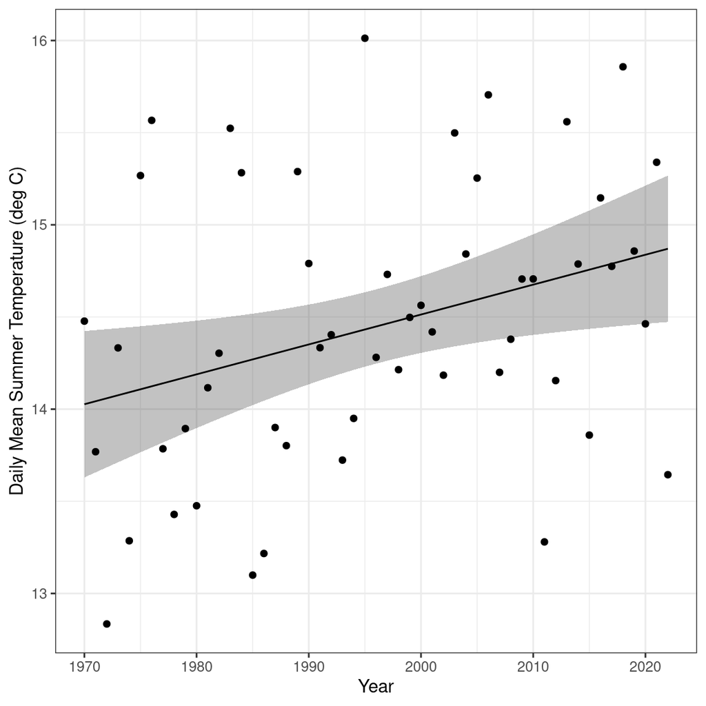

```r
ggplot(data=dublin_climate,            # Define the data to be plotted
       aes(x=year,
           y=pred,
           ymin=pred_lwrCI,
           ymax=pred_uprCI)) +

  # Specify the plot
  geom_ribbon(alpha=0.3) +               # Make 95% CI semi-transparent
  geom_path() +                          # Plot the predicted linear relationship
  geom_point(aes(y=summer_dailyTmean)) + # Plot the original data

  # Specify the styling of the plot
  labs(x='Year',
       y='Daily Mean Summer Temperature (deg C)') +
  theme_bw()
```

### Figure caption

The figure needs a caption, which could be:

> Figure 1: The linear increase in daily summer temperature for Dublin between 1970 and 2022 (F<sub>1,51</sub>=6.1, p=0.017). Shown are the data (solid points), the predicted relationship (solid line) and its 95% confidence interval (shaded region).

# Practise Tasks

Analyse climate data for a city other than Dublin and quantify the temperature change per year

### First part: Prepare the data

1. Create a new R script, import the climate_change.csv data
2. Subset your imported data so it contains data from just one European city (not Dublin)
3. Produce a figure that shows the data for mean daily temperature between 1970 and 2022 (you can pick either winter or summer).

### Second part: Fit a linear model

4. Use the lm() function to fit a straight-line relationship (i.e. a linear regression) between the variables year (x-axis) and the temperature you visualised in task 3 (y-axis)
5. Produce validation plots for your fitted model and interpret the plots

### Third part: Interpret the fitted model

6. Estimate the rate of change of temperature (degrees C per year) for your chosen city between 1970 and 2022.
7. Write up your result in a format that is appropriate for a professional report. You can include a figure to accompany your result.

# Summary and Key Take-Home Points

- There are four steps to data analysis workflow
  1. Organise your data
  2. Import and wrangle your data into a workable format
  3. Explore your data using graphs and summary statistics
  4. Formally analyse your data, focussing on the hypothesis
- General linear models are a first choice for analysing a quantitative response variable
- General linear models can have quantitative and qualitative explanatory variables (this corresponds to the classical analyses of regression and ANOVA, respectively)
- Before an analysis can be used to draw conclusions the model must be validated
- There is an accepted professional format for reporting the conclusions from an analysis